# R Notebook

# Exploratory Data Analysis

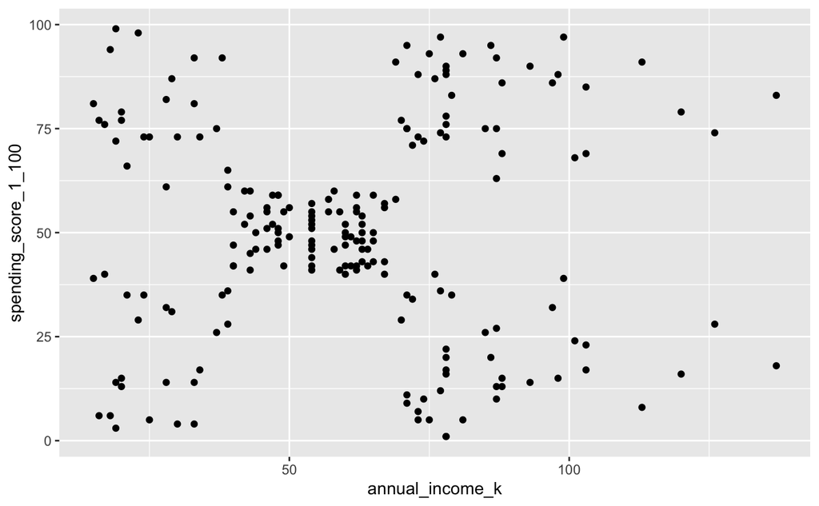

**Interpretation**

Scatter plot appears to show data would be appropriate to cluster, potentially 5 distinct clusters?

# K-means clustering

| totss | tot.withinss | betweenss | iter |
| --- | --- | --- | --- |
| 269981.3 | 24986.53 | 244994.8 | 3 |

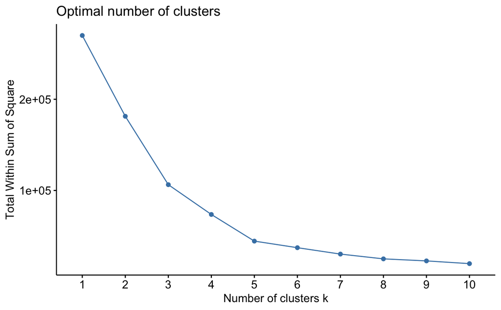

```r
fviz_nbclust(customers_numeric,
             kmeans,
             method = "wss",
             nstart = 25)
```

**Interpretation**

Shows the decrease of within sum of squares as we increase the number of clusters. We can see there is diminishing returns as we hit 5-7 clusters.

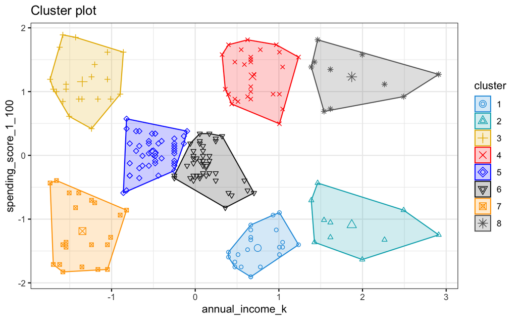

```r
fviz_cluster(clustered_customers, customers_numeric,
             palette = c("#2E9FDF", "#00AFBB", "#E7B800", "red", "blue",
                         "grey10", "orange", "grey40"),
             geom = "point",
             ellipse.type = "convex",
             ggtheme = theme_bw()
             )
```

**Interpretation**

This plot shows the points and how they have been clustered. It actually gives me reason to believe clustering is not the best idea for this data due to the following observations:

- We have uneven sized clusters, some > 40, some < 15.
- Appears to give more weight to larger clusters, smaller clusters have a greater within ss.

We can also start to label the clusters based on their location. The top right light grey star cluster is those grouped with high annual income and high spending score, the elites. Where as in the bottom left in orange there are those with the lowest income and amongst the lowest spending score, the have nots. I will name the green triangle cluster as the thrifty bunch, ie, high annual income and low spending score.

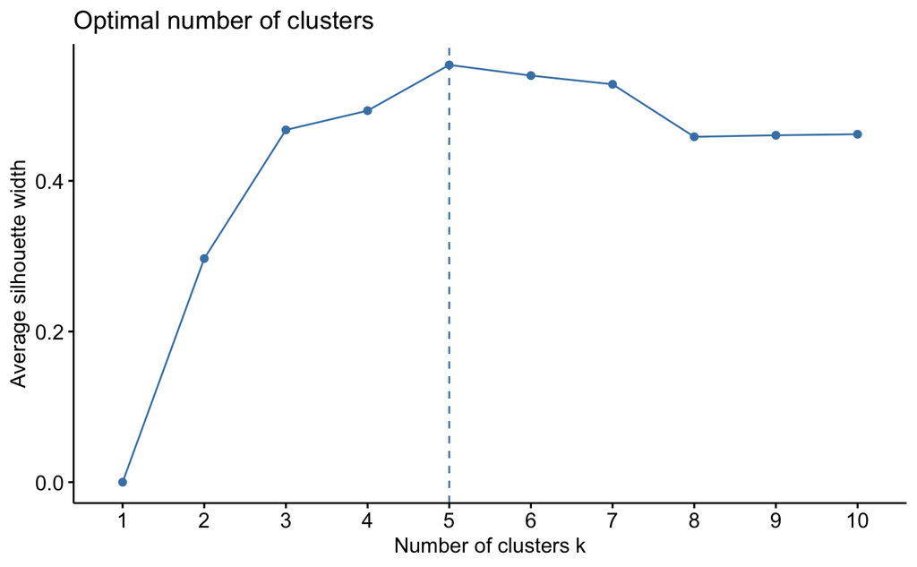

```r
fviz_nbclust(customers_numeric,
             kmeans,
             method = "silhouette",
             nstart = 25)
```

**Interpretation**

This silhouette coefficient shows us the optimal number of clusters appears to be 5.